# CMA Exercise 2

Linus Rüegg

4/30/2021

```r
wildschwein_BE <- read_delim("wildschwein_BE_2056.csv",",")
wildschwein_BE <- st_as_sf(wildschwein_BE, coords = c("E", "N"), crs = 2056, remove = FALSE)
wildschwein_BE
```

```
## Simple feature collection with 51246 features and 6 fields
## Geometry type: POINT
## Dimension:     XY
## Bounding box:  xmin: 2568153 ymin: 1202306 xmax: 2575154 ymax: 1207609
## Projected CRS: CH1903+ / LV95
## # A tibble: 51,246 x 7
##    TierID TierName CollarID DatetimeUTC                E        N
##  * <chr>  <chr>       <dbl> <dttm>                 <dbl>    <dbl>
##  1 002A   Sabi        12275 2014-08-22 21:00:12 2570409. 1204752.
##  2 002A   Sabi        12275 2014-08-22 21:15:16 2570402. 1204863.
##  3 002A   Sabi        12275 2014-08-22 21:30:43 2570394. 1204826.
##  4 002A   Sabi        12275 2014-08-22 21:46:07 2570379. 1204817.
##  5 002A   Sabi        12275 2014-08-22 22:00:22 2570390. 1204818.
##  6 002A   Sabi        12275 2014-08-22 22:15:10 2570390. 1204825.
##  7 002A   Sabi        12275 2014-08-22 22:30:13 2570387. 1204831.
##  8 002A   Sabi        12275 2014-08-22 22:45:11 2570381. 1204840.
##  9 002A   Sabi        12275 2014-08-22 23:00:27 2570316. 1204935.
## 10 002A   Sabi        12275 2014-08-22 23:15:41 2570393. 1204815.
## # … with 51,236 more rows, and 1 more variable: geometry <POINT [m]>
```

# Task 1

```r
# Creating new column showing the timelag between two entries in int seconds

wildschwein_BE <- wildschwein_BE %>%
  group_by(TierID) %>%
  mutate(timelag = as.integer(difftime(lead(DatetimeUTC), DatetimeUTC, units = "secs")))
```

### How many individuals were tracked?

```r
table(wildschwein_BE$TierName)
```

```
##
##  Rosa  Ruth  Sabi
## 14364 14136 22746
```

Three, all with above 14’000 tracker fixes.

### For how long were the individuals tracked? Are there gaps?

### Were all individuals tracked concurrently or sequentially?

### What is the temporal sampling interval between the locations?

```r
wildschwein_BE %>%
  group_by(TierName) %>%
  summarise(min_time = min(DatetimeUTC),
            max_time= max(DatetimeUTC),
            Tracking_Period = difftime(max_time, min_time),
            min_lag = min(timelag, na.rm=T),
            max_lag = max(timelag, na.rm=T),
            median_lag = median(timelag, na.rm=T)
            )
```

```
## Simple feature collection with 3 features and 7 fields
## Geometry type: MULTIPOINT
## Dimension:     XY
## Bounding box:  xmin: 2568153 ymin: 1202306 xmax: 2575154 ymax: 1207609
## Projected CRS: CH1903+ / LV95
## # A tibble: 3 x 8
##   TierName min_time            max_time            Tracking_Period min_lag
##   <chr>    <dttm>              <dttm>              <drtn>            <int>
## 1 Rosa     2014-11-07 07:45:44 2015-06-29 23:45:11 234.6663 days        12
## 2 Ruth     2014-11-07 18:00:43 2015-07-27 09:45:15 261.6559 days        13
## 3 Sabi     2014-08-22 21:00:12 2015-07-27 11:00:14 338.5834 days        14
## # … with 3 more variables: max_lag <int>, median_lag <int>,
## #   geometry <MULTIPOINT [m]>
```

The Tracking_Period for each of our three boars is a bit different. Looking at min_time and max_time of the three, they were tracked concurrently. And finally looking at the timelag: There is no strict sampling interval, sometimes the next location was sampled just 12s after the previous and the most extreme gap was 60’367s long. The median timelag for all three boars was around 15min (900s).

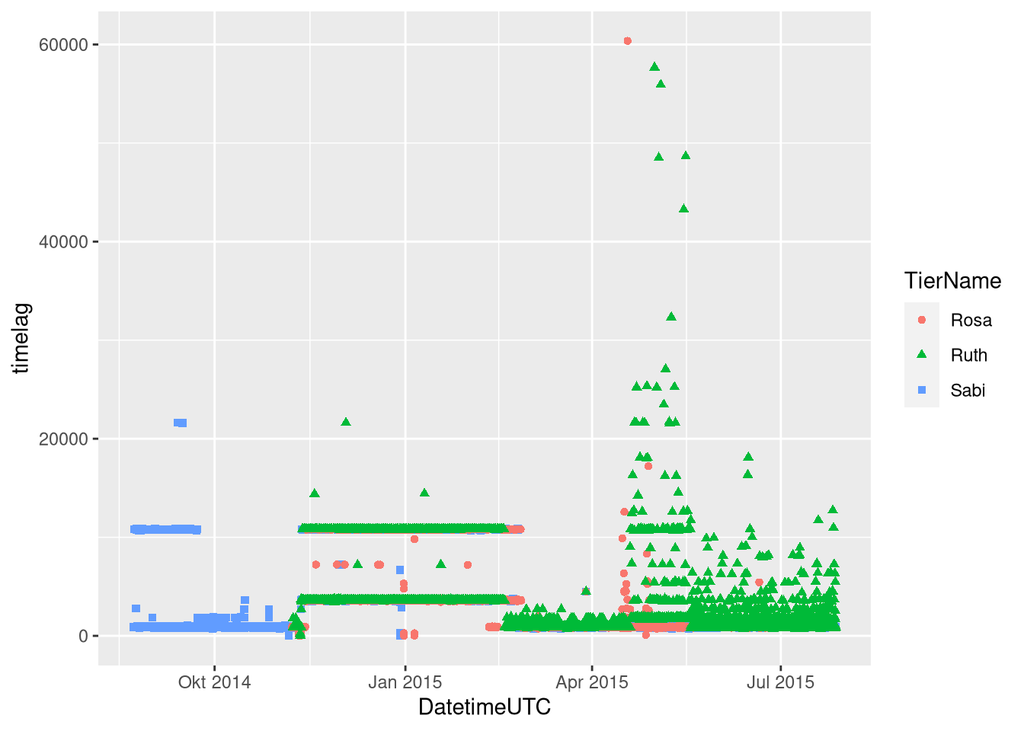

```r
ggplot(wildschwein_BE)+
  geom_point( aes(x = DatetimeUTC, y = timelag, color = TierName, shape = TierName))
```

The plot proves the assumptions done by just looking at the summary statistics.

# Task 2

```r
wildschwein_BE <-  wildschwein_BE %>%
  group_by(TierName) %>%
  mutate(steplength = sqrt((E- lead(E,1))^2 + (N -lead(N,1))^2))
```

```r
wildschwein_BE <- wildschwein_BE %>%
  group_by(TierName) %>%
  mutate(speed = steplength/timelag)
```

### What speed unit do you get?

m/s

# Task 3

```r
caro <- read_delim("caro60.csv",",")
caro <- st_as_sf(caro, coords = c("E", "N"), crs = 2056, remove = FALSE)
nrow(caro)
```

```
## [1] 200
```

```r
caro_3 <- caro[seq(1,nrow(caro),by=3),]
caro_6 <- caro[seq(1,nrow(caro),by=6),]
caro_9 <- caro[seq(1,nrow(caro),by=9),]
```

```r
nrow(caro_3)
```

```
## [1] 67
```

```r
nrow(caro_6)
```

```
## [1] 34
```

```r
nrow(caro_9)
```

```
## [1] 23
```

```r
# Caro_3
caro_3 <- caro_3 %>%
  mutate(timelag = as.integer(difftime(lead(DatetimeUTC), DatetimeUTC, units = "secs")))
caro_3 <- caro_3 %>%
  mutate(steplength = sqrt((E- lead(E,1))^2 + (N -lead(N,1))^2))
caro_3 <- caro_3 %>%
  mutate(speed = steplength/timelag)
# Caro_6
caro_6 <- caro_6 %>%
  mutate(timelag = as.integer(difftime(lead(DatetimeUTC), DatetimeUTC, units = "secs")))
caro_6 <- caro_6 %>%
  mutate(steplength = sqrt((E- lead(E,1))^2 + (N -lead(N,1))^2))
caro_6 <- caro_6 %>%
  mutate(speed = steplength/timelag)
# Caro_9
caro_9 <- caro_9 %>%
  mutate(timelag = as.integer(difftime(lead(DatetimeUTC), DatetimeUTC, units = "secs")))
caro_9 <- caro_9 %>%
  mutate(steplength = sqrt((E- lead(E,1))^2 + (N -lead(N,1))^2))
caro_9 <- caro_9 %>%
  mutate(speed = steplength/timelag)
# Caro
caro <- caro %>%
  mutate(timelag = as.integer(difftime(lead(DatetimeUTC), DatetimeUTC, units = "secs")))
caro <- caro %>%
  mutate(steplength = sqrt((E- lead(E,1))^2 + (N -lead(N,1))^2))
caro <- caro %>%
  mutate(speed = steplength/timelag)
```

### Plotting

```r
caro_l <- caro %>%
  group_by() %>%
    summarise(do_union = FALSE) %>%
      st_cast("LINESTRING")

caro_l_3 <- caro_3 %>%
  group_by() %>%
    summarise(do_union = FALSE) %>%
      st_cast("LINESTRING")

caro_l_6 <- caro_6 %>%
  group_by() %>%
    summarise(do_union = FALSE) %>%
      st_cast("LINESTRING")

caro_l_9 <- caro_9 %>%
  group_by() %>%
    summarise(do_union = FALSE) %>%
      st_cast("LINESTRING")
```

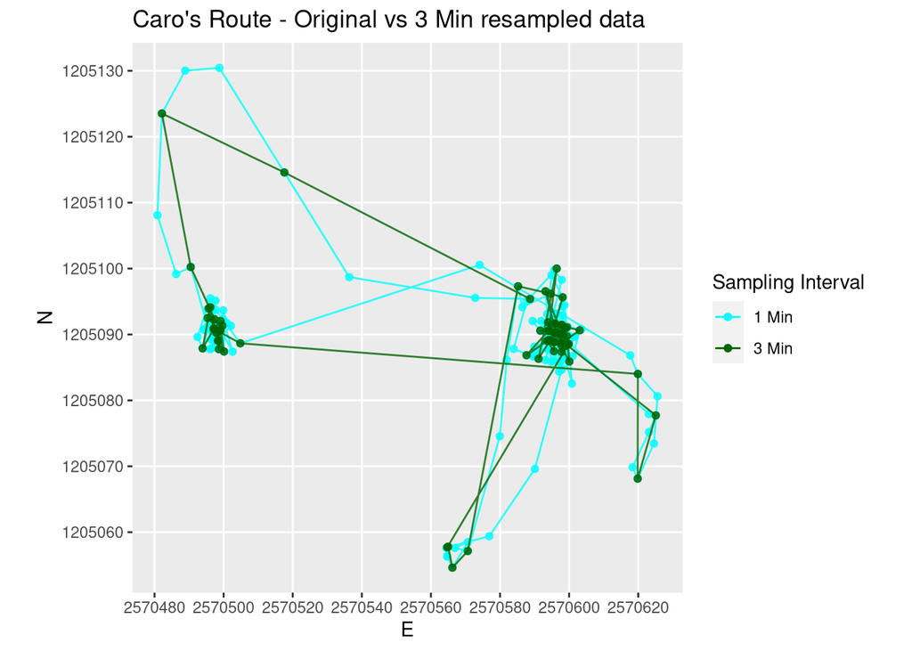

```r
ggplot() +
  ggtitle("Caro's Route - Original vs 3 Min resampled data")+
  xlab("E")+
  ylab("N")+
  theme_set(theme_minimal()) +
  theme(aspect.ratio=1) +
  geom_sf(data = caro, aes(color = "1 Min"), alpha = 0.8) +
  geom_sf(data = caro_l, aes(color = "1 Min"), alpha = 0.8) +
  geom_sf(data = caro_3, aes(color = "3 Min"), alpha = 0.8)+
  geom_sf(data = caro_l_3, aes(color = "3 Min"), alpha = 0.8)+
  coord_sf(datum = 2056) +
  scale_color_manual(name = "Sampling Interval", breaks = c("1 Min", "3 Min"), values = c("1 Min" = "cyan", "3 Min" = "darkgreen"))
```

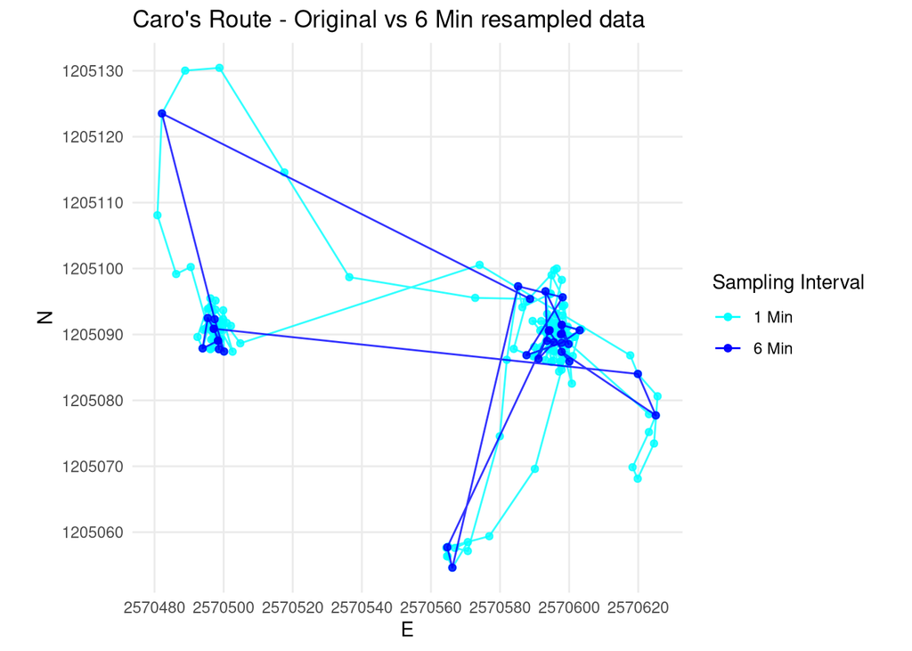

```r
ggplot() +
  ggtitle("Caro's Route - Original vs 6 Min resampled data")+
  ylab("N")+
  xlab("E")+
  theme_set(theme_minimal()) +
  theme(aspect.ratio=1) +
  geom_sf(data = caro, aes(color = "1 Min"), alpha = 0.8) +
  geom_sf(data = caro_l, aes(color = "1 Min"), alpha = 0.8) +
  geom_sf(data = caro_6, aes(color = "6 Min"), alpha = 0.8)+
  geom_sf(data = caro_l_6, aes(color = "6 Min"), alpha = 0.8)+
  coord_sf(datum = 2056) +
  scale_color_manual(name = "Sampling Interval", breaks = c("1 Min", "6 Min"), values = c("1 Min" = "cyan", "6 Min" = "blue"))
```

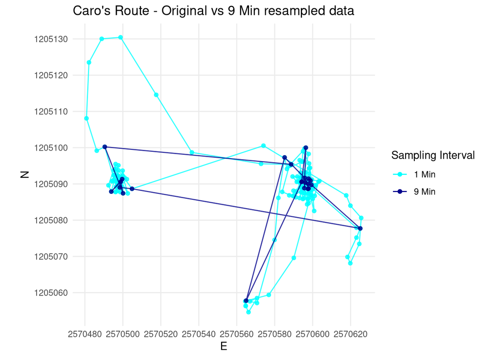

```r
ggplot() +
  ggtitle("Caro's Route - Original vs 9 Min resampled data")+
  ylab("N")+
  xlab("E")+
  theme_set(theme_minimal()) +
  theme(aspect.ratio=1) +
  geom_sf(data = caro, aes(color = "1 Min"), alpha = 0.8) +
  geom_sf(data = caro_l, aes(color = "1 Min"), alpha = 0.8) +
  geom_sf(data = caro_9, aes(color = "9 Min"), alpha = 0.8)+
  geom_sf(data = caro_l_9, aes(color = "9 Min"), alpha = 0.8)+
  coord_sf(datum = 2056) +
  scale_color_manual(name = "Sampling Interval", breaks = c("1 Min", "9 Min"), values = c("1 Min" = "cyan", "9 Min" = "darkblue"))
```

One can see less and less movement by increasing the sampling interval steps. This makes sense, as we loos points, which could be plotted in the end.

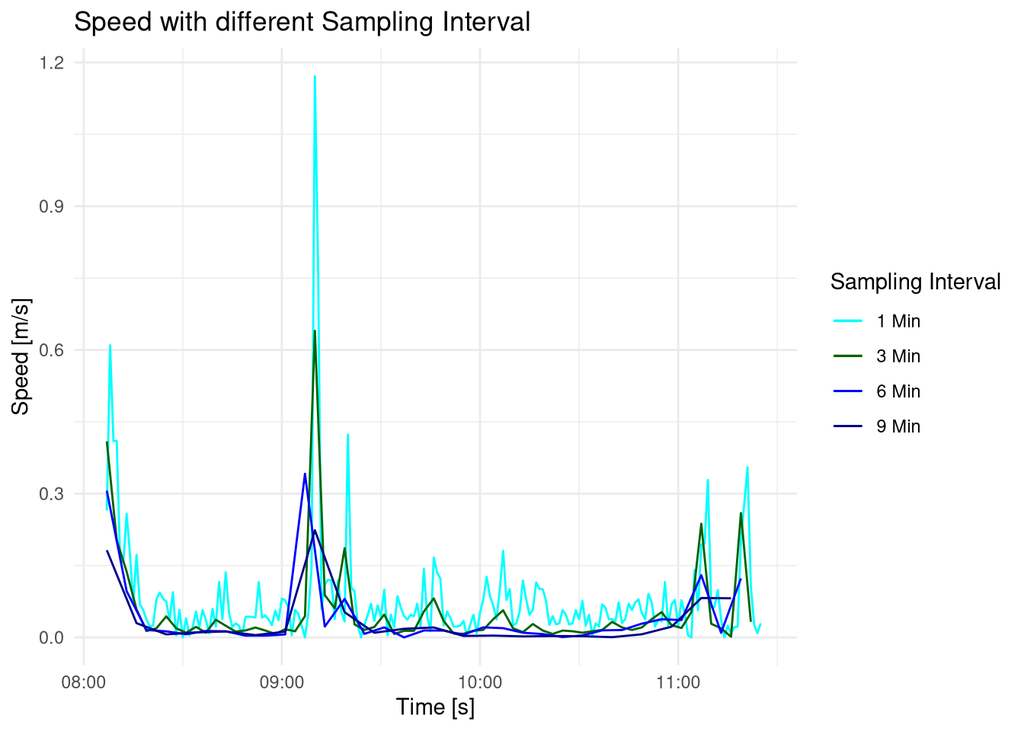

```r
ggplot()+
  ggtitle("Speed with different Sampling Interval")+
  ylab("Speed [m/s]")+
  xlab("Time [s]")+
  theme_set(theme_minimal()) +
  geom_line(data = caro, aes(x = DatetimeUTC, y = speed, color ="1 Min"))+
  geom_line(data = caro_3, aes(x = DatetimeUTC, y = speed, color ="3 Min"))+
  geom_line(data = caro_6, aes(x = DatetimeUTC, y = speed, color ="6 Min"))+
  geom_line(data = caro_9, aes(x = DatetimeUTC, y = speed, color ="9 Min"))+
  scale_color_manual(name = "Sampling Interval", breaks = c("1 Min","3 Min", "6 Min","9 Min"), values = c("1 Min" = "cyan", "9 Min" = "darkblue", "6 Min" = "blue", "3 Min" = "darkgreen"))
```

Like with the trajectory line plots, we see a smoother picture here too, when increasing the sampling interval. Also, we seem to always hit the lower speeds while sampling with bigger step sizes. Even though the original sample step size of one minute shows some far faster speeds. This might lead to misinterpretations and should be avoided by always looking at (at least a subset) of the original data.

# Task 4

```r
library(zoo)
example <- rnorm(10)
rollmean(example,k = 3,fill = NA,align = "left")
```

```
##  [1] -0.67440493 -0.57485701 -0.04527114  0.11864299  0.05567541  0.31681943
##  [7]  0.32381440 -0.05792887          NA          NA
```

```r
##  [1]  0.93634335  0.31709038  0.02370048  0.67869801  0.73369105  0.50401344
##  [7] -0.56144365 -0.56902598          NA          NA
rollmean(example,k = 4,fill = NA,align = "left")
```

```
##  [1] -0.32311703 -0.48923939 -0.06956115  0.22444323  0.17951793  0.20725301
##  [7]  0.09201434          NA          NA          NA
```

```r
##  [1]  0.6775521  0.2045005  0.5848215  0.5255629  0.3446928  0.1459635
##  [7] -0.4102301         NA         NA         NA
```

```r
carorw <- caro %>%
  mutate(k3 = rollmean(speed, k= 3, fill = NA, align = "left"),
          k6 = rollmean(speed, k= 6, fill = NA, align = "left"),
          k15 = rollmean(speed, k= 15, fill = NA, align = "left"),
          k30 = rollmean(speed, k= 30, fill = NA, align = "left"))
```

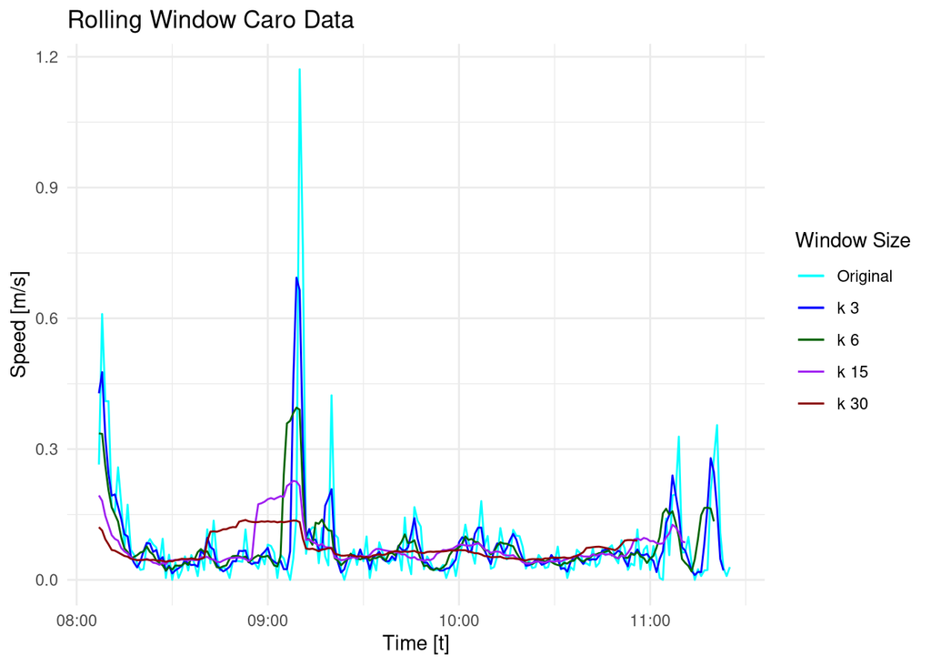

```r
ggplot(data = carorw)+
  ggtitle("Rolling Window Caro Data")+
  ylab("Speed [m/s]")+
  xlab("Time [t]")+
  theme_set(theme_minimal()) +
  geom_line(aes(x = DatetimeUTC, y = speed, color ="Original"))+
  geom_line(aes(x = DatetimeUTC, y = k3, color ="k 3"))+
  geom_line(aes(x = DatetimeUTC, y = k6, color ="k 6"))+
  geom_line(aes(x = DatetimeUTC, y = k15, color ="k 15"))+
  geom_line(aes(x = DatetimeUTC, y = k30, color ="k 30"))+
  scale_color_manual(name = "Window Size", breaks = c("Original","k 3", "k 6","k 15", "k 30"), values = c("Original" = "cyan", "k 15" = "purple", "k 6" = "darkgreen", "k 3" = "blue", "k 30" = "darkred"))
```

The moving window is a good example, on how data can be simplified without eventually loosing the gist. Here, the bigger window sized graphs do not indicate a much lower speed as the higher sampling step sizes did in Task 3. k3 trough k30 much better represent the original graph than the increased sampling step sized graphs.